# Exploring Next Generation Sequence data with the Linux command line

# Fantastic arrays and how to loop over them

## Array structures

When we counted reads in different quality groups, we had just two groups, so it was easy to create two counter variables, and write two print statements at the end. But what if we wanted to count a million different categories of thing? For example, what about counting the reads mapping to each of seven chromosomes? We need a kind of storage system. We need an *array*.

It’s a bit like the array is a train with labelled carriages carrying information. Information you can access if you give the name of the train, and of the carriage:

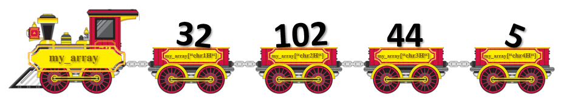

Yes, I know this is a bit childish but it’s how I learned about arrays and I like it.

An array is a kind of variable with labelled slots in it, that can be accessed using that label. If I create an array called “my_array”, I could name the slots after, say, the chromosomes. And in each slot we could store the number of reads mapping to that particular chromosome. When accessing the slots of an array in awk, we type the array’s name, followed by square brackets, and inside those, the slot name.

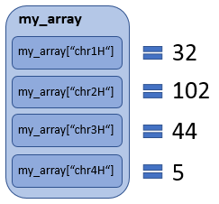

So using this array as an example, if part of my awk program was `print my_array["chr2H"]`, it would print “102”, and if part of my program was `my_array["chr2H"] = my_array["chr2H"] + 5` it would add five to the value, so the next `print my_array["chr2H"]` would produce “107”.

You don’t need to set up awk arrays at the beginning of the program, you just start using them and awk automatically sets them up for you. So, to count reads hitting chromosomes, we can use the chromosome names (stored in $3) as slot labels in an array (I will call it “chr_counts”), like this:

```bash
#Remember: condition "1" means "run this command for every line"
cat data/HOR_1251_mapped_to_reference_genome.sam | awk '1 { chr_counts[$3] = chr_counts[$3] + 1 }'
```

This is great, but it simply creates the array, and never prints anything! But since yopu now know how to print the contents of an array slot, you can do this yourself:

#### Exercise

- Modify the command to print the counts for chromosome 6H at the end.
  - HINT: The condition `END` is used for commands that should be run only at the end of the program (i.e. after every line of the file has been read).
- Add a print statement to also print the count for chromosome 4H.
  - HINT: Remember multiple commands must be separated by the semicolon (`;`).
- Write an awk program to count the numbers of reads of each quality (the quality scores are in column 5), then print the counts of reads of quality 38, and quality 60.
- Modify that program to count only the quality scores for chromosome 1H.
- To print more than one item in the same row, separate the items by commas. Modify your print commands to print first the quality score (38 or 60), then the count of reads with that quality score.

## Looping

If we wanted to print the number of reads of every single chromosome, we’d need to write many print statements, one for each chromosome. But what if we don’t even know what qualities are in the data? What if there are 100 different chromosomes? This would be almost impossible.

What we really need is a way to repeat a command (in this case, printing something), but very slightly change the command each time. In this case we want to run it once for each chromosome, and use each chromosome name as the label of the array slot to be printed.

Let’s say we found a way to cycle through the labels, and for each one, we would store the label name in a variable called `i`. So `i` would first contain “chr1H”, and we could write `print my_array[i]` to print out the contents of `my_array["chr1H"]`. Then we set `i` to “chr2H”, and repeat the process. And again and again until every label has been used … like this:

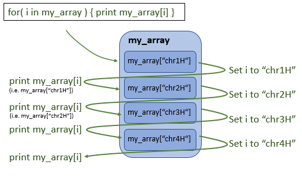

This is called a *loop* (specifically, a *for* loop), and the way to describe one is written at the top. Start with “for”. In brackets, we write what we want our *indexing* varaiable to be called (this is `i` in this example), then “in” and the name of the array we are going to loop over. The command to be run each time is written in curly braces (`{...}`).

#### Exercises

- Try adding a loop to the `END` section of the chromosome read-counting program above, that prints the counts for each chromosome.
  - ANSWER: cat data/HOR_1251_mapped_to_reference_genome.sam | awk ‘1 {chr_counts[$3] = chr_counts[$3]+1} END { for(i in chr_counts){ print chr_counts[i] } }’
- Since `i` contains the chromosome names, modify the script to print the chromosome name before the count of that chromosome on each line.
  - HINT: Remember you can print separate items on the same line by separating them with commas.
  - ANSWER: cat data/HOR_1251_mapped_to_reference_genome.sam | awk ‘1 {chr_counts[$3] = chr_counts[$3]+1} END { for(i in chr_counts){ print i,chr_counts[i] } }’
- In many programming languages, addin one to a variable is so common, that a shortcut exists. Instead of `variable=variable+1`, we can just write `variable++`. Modify the chromsome counting part of the last awk program to use this shortcut.

# Nucleotide evolution: A study using nested for loops on a .vcf file

The .vcf file tells us about genetic variablility in a dataset. So far, we used that to explore evolution, and to look for possible associations between the characteristics of an individual and the sequence of its genome. But what about questions of biochemistry? Could we use this dataset to tell us something about the molecular properties of DNA molecules?

Mutation happens when there is a copying error in the germline cells. There is a hypothesis that, in general, the *purine* bases (A and G) are more likely to be mistakenly copied in place of each other, because they are chemically similar. So, a G is more likely to mutate into an A, than into a C or T. Similarly, a *pyrimidine* (C or T) is more likely to be mutated into a different pyrimidine.

#### Exercise

- Write an awk program to count the occurences of each reference allele in the .vcf file, and then print the counts at the end.
  - HINT: Use an array to store the counts, and a loop to print them
  - ANSWER: (uses the array name “counts”): cat data/Panel_variant_calls.vcf | awk ‘1 {counts[$4]++} END { for(i in counts){ print i,counts[i] } }’

This is called a two-dimentional array, and it’s simpler to use than than it sounds. We just use a second set of square brackets to specify the slot in the second array. To visualise it, just think of a grid:

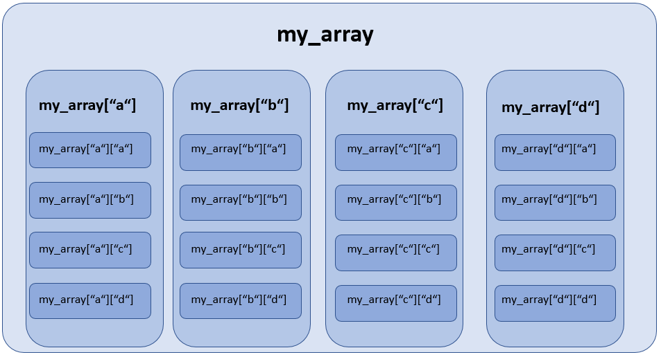

And what about printing it out? To print the array, we used a loop. And to print an array inside an array … we just use a loop inside a loop. Each time the outer loop increments one variable (say, `i`), another loop will be run to increment over a second variable, say, `j`. Once again, this is easier to visualise:

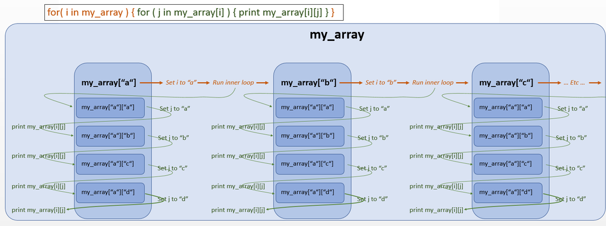

```bash
cat data/Panel_variant_calls.vcf | awk '{nt_counts[$4][$5]++} END {for (i in nt_counts) { for (j in nt_counts) {print i,j,nt_counts[i][j]+nt_counts[j][i]} } }'
```

# Tying it all together

```r
#KASP marker selection and design, automated.
  #Assumes a single chromosome only in the vcf.
  #Filters out heterozygotes for pseudo-haploid dataset

#load my toolkit
source("https://raw.githubusercontent.com/mtrw/tim_r_functions/master/tim_functions.R")

#Set home directory
setwd("~")

#get SNP table (derived from downloading imputed SNP sets for the core 200 (w photos only) from bridge.ipk-gatersleben.de) and parsing with bin/vcf_listify_for_R_BRIDGE_imputed.awk, as in, the command will be "zcat bridge_snp_export.vcf.gz | bin/vcf_listify_for_R_BRIDGE_imputed.awk > bridge_snp_export.tsv"
s <- fread( "/filer/projekte/ggr-course2020/data/bridge_snp_export.tsv" , select=c(1:6) , col.names = c("chromosome","position","allele_1","allele_2","sample","genotype") , colClasses = c("character","integer","character","character","character","integer") , na.strings = "" )

s

#kill samples/snps wih lots of missing data
badsamp <- s[ , .(pna=sum(is.na(genotype))/.N) ,by=.(sample)][ pna>.05 ]
s <- s[!(sample %in% badsamp$sample)]
badsamp
badsnp <- s[ , .( pna=sum(is.na(genotype)) + sum(genotype==1,na.rm = T) ) , by=.(position)][ pna!=0 ]
s <- s[!(position %in% badsnp$position)]
badsnp
badmaf <- s[ , .(maf=minor_allele_frequency(genotype)) , by=.(position) ][ maf < 0.1 ]
s <- s[ !(position %in% badmaf$position) ]
badmaf
#set allele 1 to minor and 0 to major
s[ ,  ma := minor_allele(genotype) , by=.(position) ]
s[ ,  genotype := ifelse( ma==genotype , 1L , 0L ) ]
s[ , ma := NULL ]


#add simplified position indicies
s[ , position_simplified := frank(position,ties.method = "dense")]

#have a look at the first 199 SNP positions
ggplot( data = s[position_simplified<200] , aes( x=position_simplified , y=sample , colour=as.factor(genotype)  ) ) + geom_point()

#Do a PCA and distmatrix for starters ... to help choose samples and SNPs
sc <- dcast( s[,-c("allele_1","allele_2","position","chromosome")] , sample ~ position_simplified , value.var = "genotype" )
sm <- sc[,-"sample"] %>% as.matrix
row.names(sm) <- sc$sample
  #have a look for sanity purposes
sm[1:10,1:10]
spca <- prcomp(sm)
null_plot( x = spca$x[,1] , y = spca$x[,2] )
text( x = spca$x[,1] , y = spca$x[,2] , labels = spca$x %>% rownames() )

#distance matrix and dendrogram
dm <- dist(sm)
hclust(dm) %>% plot


#change these lines so that "suggested_samples" ends up as a vector of the names of the samples you want to work with
key_set <- paste0("HOR_",  c( 3728 , 13924 , 3912   , 1384 ,  3686  ,  3926 , 15898 , 2403  , 5876 , 1251 , 7428 , 11922 ))
extra_set <- paste0("HOR_",c( 12311 , 10702  , 7474 ,  16078 ,  11448 ,  13724    ,    13716   ,   14914   , 11875 ,  7172 , 7552  ))
suggested_samples <- c(key_set,extra_set)
#change these lines so that "poss" ends up as a vector of the poisition coordinates of the samples you want to work with
suggested_poss <- c(38650183 , 10965722 , 53877317 , 7426630 , 20345869 , 33855250 , 15066049 , 2477869 , 22018710 , 2113018 , 11208037 , 4183083 , 8468722 , 31344580 , 19268657 , 2480427 , 7222038 , 53849247 , 42468659 , 38063434)

#this command will print a list of samples to a table
#write.table(data.table(suggested_samples),file=file.path("samples_for_marker_genotyping.csv"),col.names=F,row.names=F)

#"sf" means "s-filtered". It includes only your chosen positions and samples
sf <- s[sample %in% suggested_samples & position %in% suggested_poss ]#[[try]]
sf[ , position_simplified := frank(position,ties.method = "dense") ]



#PCA and distmat to see how that might go
sfc <- dcast( sf[,-c("allele_1","allele_2","position","chromosome")] , sample ~ position_simplified , value.var = "genotype" )
sfm <- sfc[,-"sample"] %>% as.matrix
row.names(sfm) <- sfc$sample

#visualise part of the matrix
sfm[1:10,1:10]

#calculate the PCA
sfpca <- prcomp(sfm)

#plot PCA
null_plot( x = sfpca$x[,1] , y = sfpca$x[,2] )
text( x = sfpca$x[,1] , y = sfpca$x[,2] , labels = sfpca$x %>% rownames() )

#graphical genotypes of selected set
ggplot( data = sf , aes( x=position , y=sample , colour=as.factor(genotype)  ) ) + geom_point()

#dendrogram of selected set
dfm <- dist(sfm)
hclust(dfm) %>% plot


#make bed file, extract sequences from the genome file, add ambiguity and focal SNP notation (required by KASP marker provider), output in fasta format
#this requires that A) the path to bedtools is correct, B) the path to the reference genome is correct  C) the index for the reference genome is in the same path, D) the output file name is writeable. set them all in the below loop
sf[, {
  ce("Beginning extraction of sequence at SNP position ",position)
  a <- paste(c(allele_1[1],allele_2[1]) ,collapse="-")
  ce( "Position: " , position , "\tRef/Alt allele: " , a )
  dt <- data.table(chr="chr1H",start=position-1-100,end=position+100,name=paste0("SNP_",.GRP,"_Hv_chr1_pos:",position,"_alleles:",a))
  tf <- tempfile()
  ce("Writing marker co-ordinates to temporary file: ",tf)
  #print(dt)
  write.table(x = dt,file=tf,sep = "\t",quote=F,row.names = F,col.names = F)
  ce("Calling this Linux command to Bedtools: ")
  paste0("/opt/Bio/bedtools/2.26.0/bin/bedtools getfasta -name -fi /filer/projekte/ggr-course2020/data/morex_pseudomolecules_mascheretal17.fasta -bed ",tf) %>% print
  fa <- system(paste0("/opt/Bio/bedtools/2.26.0/bin/bedtools getfasta -name -fi /filer/projekte/ggr-course2020/data/morex_pseudomolecules_mascheretal17.fasta -bed ",tf) , intern = T )

  #identifying other SNPs near this position
  pos <- position
  other_snps <- s[position != pos & position %between% c(pos-1-100,pos+100) & sample %in% unique(sf$sample),.(
    frag_pos = 101 - (position-pos),
    iupac = paste0(sort(c(allele_1[1],allele_2[1])),collapse="") %>% IUPAC %>% tolower,
    idx = .GRP
  ),by=.(position)]
  ce("These other SNPs found, replacing them with IUPAC ambiguity codes")
  print(other_snps)

  if(nrow(other_snps)>0){
    other_snps[,{
      #print(fa[2])
      #print(iupac)
      #substr(fa[2],frag_pos,frag_pos) %>% print
      #print(frag_pos)
      substr(fa[2],frag_pos,frag_pos) <<- iupac
      #substr(fa[2],frag_pos,frag_pos) %>% print
    },by = .(idx)]
  }


  seq <- paste0(substr(fa[2],1,100),"[",allele_1[1],"/",allele_2[1],"]",substr(fa[2],102,201))
  ce("Writing extracted sequence: ")
  cat(fa[1],"\n",seq,"\n")
  ce("Deleting temporary file")
  unlink(tf)
  ce("------------------------- Marker ", fa[1] , " complete! -------------------------\n\n\n\n\n")
}  , by=.(position)] %>% invisible
```